# COVID-19 Pandemic in the Republic of Kazakhstan

# 1.Background

## 1.1 Introduction

A cluster of cases of unknown cause pneumonia was reported to the World Health Organization on 31 December 2019 in the city of Wuhan, Hubei province in China. A previously unknown new virus was identified in January 2020, later named the 2019 novel coronavirus, and samples from cases and genetic analysis of the virus indicated this was the cause of the outbreak. This novel corona virus was named by WHO in February 2020 as corona virus Disease 2019 (COVID-19). The virus is known as SARS-CoV-2 and the associated disease is COVID-19.

## 1.2 Location of Kazakhstan

Kazakhstan returned to a country-wide lockdown on July 5 as COVID-19 cases sprung up. The first lockdown of the country lasted from March 16th through May 11th. The second lockdown, which is scheduled to last at least two weeks, seems to be the world’s first such reimposition of a nationwide lockdown.The two-week lockdown that could be extended if the virus continues to spread is restricting public gatherings and banning family and holiday gatherings. Citizens over 65 are expected to stay at home but others are allowed to practice alone outdoors.

The number of cases of coronavirus in Kazakhstan has been increasing tenfold since the lifting of the first lockdown measures began. Kazakhstan had registered 5,207 cases of coronavirus and 32 deaths by May 11, the last day of state of emergency and lockdown. As of 13 July in the country there were 59,899 confirmed cases of coronavirus and 375 deaths. But the situation is rapidly evolving and could be a lot worse than this.

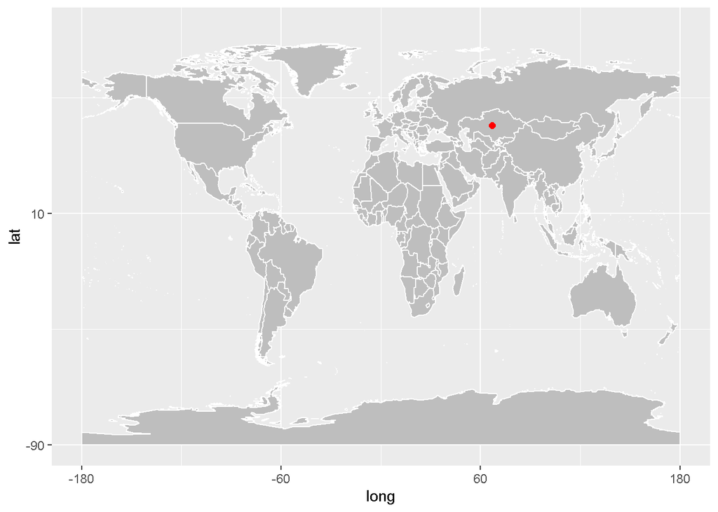

## 1.3 Climate Change in Kazakhstan

Kazakhstan, a vast country of Central Asia, has a markedly continental climate, with very cold winters almost everywhere, while summers are warm in the north and definitely hot in the south. There are no obstacles that could protect the country from cold air masses of polar or Siberian origin, while in summer, hot winds from the Iranian deserts can blow. In addition, because of the huge distance from the oceans, the Asian continent cools down a lot in winter and heats up in summer, so, both the highest and the lowest records are noticeable. In fact, in the north, the temperature can reach -40 °C (-40 °F) in winter and 40 °C (104 °F) in summer, while in the south, it can go from -35 °C (-31 °F) in winter to 45 °C (113 °F) in summer. The clash between different air masses can give rise to strong winds and dust storms, especially in spring and in the south, while in winter, the northern wind can cause snow storms, but without great accumulation on account of the scarcity of precipitation.

## 1.4 Demographics of Kazakhstan

The current population of Kazakhstan is 19,408,414 based on projections of the latest United Nations data. The UN estimates the July 1, 2022 population at 19,397,998.

The ethnic majority of the country is the ethnic Kazakhs (63.1%), although there are a large number of other ethnicities present as well, such as ethnic Russians (23.7%), Uzbeks (2.9%), Ukrainians (2.1%), Uygurs (1.4%), Tatars (1.3%) and Germans (1.1%).

Some minority groups in Kazakhstan, including Germans, Ukrainians, Chechens, Koreans, and Meskhetian Turks were deported to Kazakhstan in the 1930s and 1940s by Stalin as Russian political opponents.

At the end of the 1980s, ethnic Russians were at almost 38% of the population while Kazakhstanis were in a majority in just 7 of the country’s 20 regions. There were also 1 million Germans in Kazakhstan prior to 1991. After the Soviet Union dissolved, most emigrated to Germany. Emigration of Russians and Germans returned indigenous Kazakhs to a majority in the country.

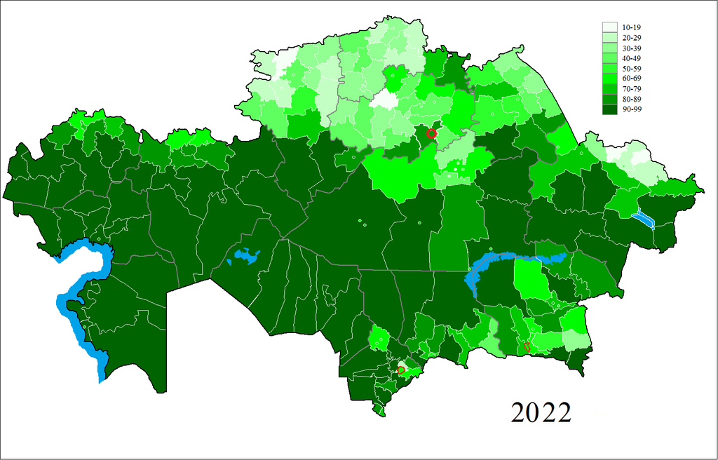

## 1.5. Lockdown status of the country

Kazakhstan returned to a country-wide lockdown on July 5 as COVID-19 cases sprung up. The first lockdown of the country lasted from March 16th through May 11th. The second lockdown, which is scheduled to last at least two weeks, seems to be the world’s first such reimposition of a nationwide lockdown.The two-week lockdown that could be extended if the virus continues to spread is restricting public gatherings and banning family and holiday gatherings. Citizens over 65 are expected to stay at home but others are allowed to practice alone outdoors.

The number of cases of coronavirus in Kazakhstan has been increasing tenfold since the lifting of the first lockdown measures began. Kazakhstan had registered 5,207 cases of coronavirus and 32 deaths by May 11, the last day of state of emergency and lockdown. As of 13 July in the country there were 59,899 confirmed cases of coronavirus and 375 deaths. But the situation is rapidly evolving and could be a lot worse than this.

## 1.6. Actions taken by the government

Since the beginning of the pandemic, Kazakh authorities have taken a number of socio-economic measures. The country has had a state of emergency for about two months. Operations in Quarantine are ongoing. Despite the quarantine measures, however, the spread of the virus has recently been accelerating. The number of infected people already is around 20,000. Over a hundred people died of the disease. For people that’s very worrying.  
The epidemic did not go through government representatives at different levels. On 15 March Kazakhstan declared a state of emergency. Exports of some key food products were banned, while food and freight imports were maintained, and a food price cap was introduced. The Ministry of Agriculture lifted an existing ban on meat exports on 30 March, but introduced quotas for wheat and flour exports during quarantine periods. The government has closed all frontiers for non-citizens to enter, and has put air and rail traffic on hold. According to the national railway company, however, freight traffic with China and Russia has not been affected, suggesting some private enterprises continue to operate.

# 2. Exploratory Data Analysis

## 2.1 Structure of Data

The data set used for this analysis is *The 2019 Novel corona virus COVID-19 (2019-nCoV)* data set which is easily available as an installable package in RStudio. The source of this data is Johns Hopkins University Center for Systems Science and Engineering (JHU CCSE) corona virus.

- Date
- Country
- Province/state; if available
- Latitude of center of geographic region defined by country/province
- Longitude of center of geographic region defined by country/province
- Type of reported case – confirmed, death, recovered
- Number of cases on given date
- Country code
- Country or province population

## 2.2 COVID-19 Statistics of Kazakhstan

Following table shows that COVID 19 year wise average cases of confirmed,death and recovery cases of Kazakhastan.It shows that the higher confirmed average reported in 2021 year.Not only that the higher death cases and recovery cases reported in 2021.In 2022, recovery cases is 0 and average death cases also decreased than other two years.

```
     confirmed    death recovery
2020   583.200    7.968  518.010
2021  2556.900   43.250 1042.600
2022  1854.960    4.638    0.000
```

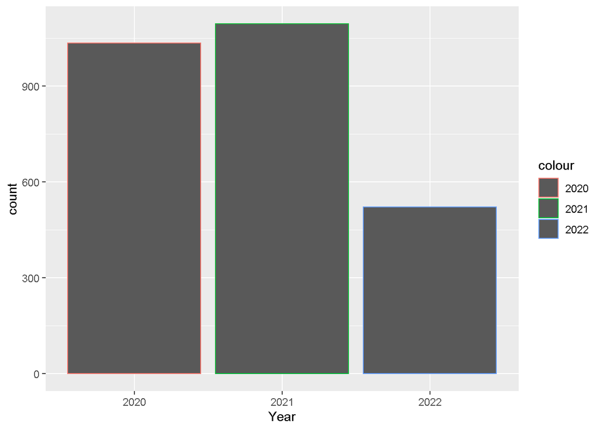

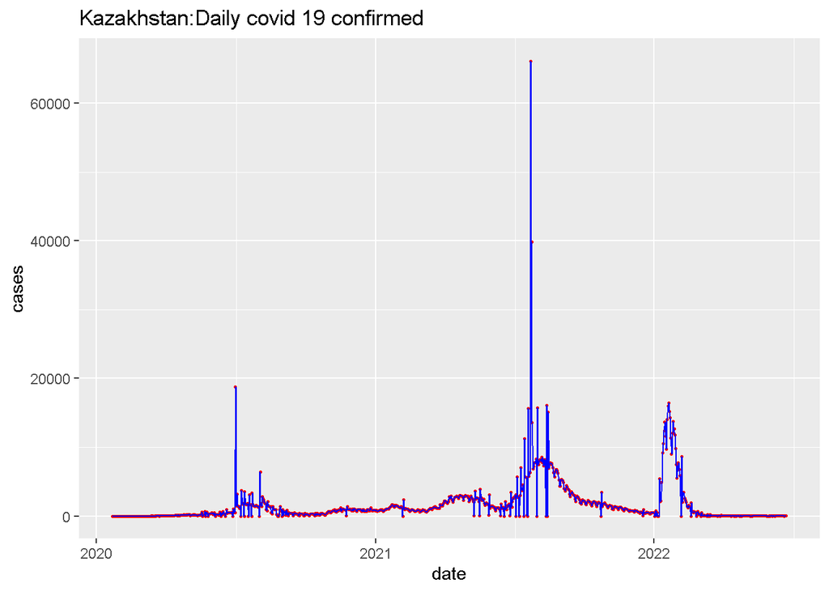

```
      date                cases           country              type
 Min.   :2020-01-22   Min.   :    0.0   Length:884         Length:884
 1st Qu.:2020-08-29   1st Qu.:   66.5   Class :character   Class :character
 Median :2021-04-07   Median :  773.5   Mode  :character   Mode  :character
 Mean   :2021-04-07   Mean   : 1690.6
 3rd Qu.:2021-11-14   3rd Qu.: 1738.5
 Max.   :2022-06-23   Max.   :66121.0
    col
 black:884
 red  :  0
```

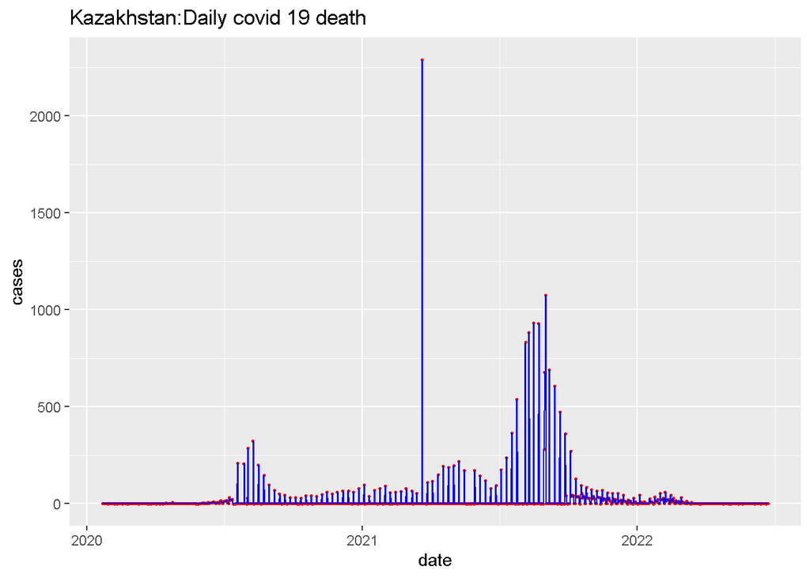

```
      date                cases          country              type
 Min.   :2020-01-22   Min.   :   0.0   Length:884         Length:884
 1st Qu.:2020-08-29   1st Qu.:   0.0   Class :character   Class :character
 Median :2021-04-07   Median :   0.0   Mode  :character   Mode  :character
 Mean   :2021-04-07   Mean   :  22.6
 3rd Qu.:2021-11-14   3rd Qu.:   2.0
 Max.   :2022-06-23   Max.   :2291.0
    col
 black:884
 red  :  0
```

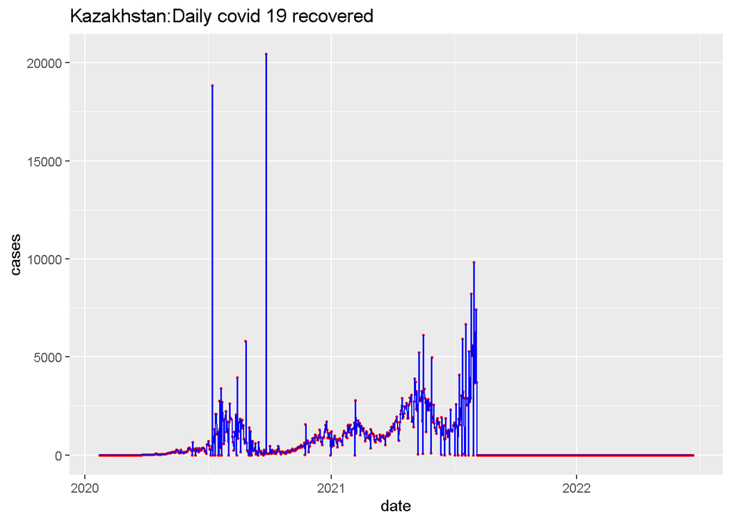

```
      date                cases           country              type
 Min.   :2020-01-22   Min.   :    0.0   Length:884         Length:884
 1st Qu.:2020-08-29   1st Qu.:    0.0   Class :character   Class :character
 Median :2021-04-07   Median :   42.0   Mode  :character   Mode  :character
 Mean   :2021-04-07   Mean   :  635.8
 3rd Qu.:2021-11-14   3rd Qu.:  887.8
 Max.   :2022-06-23   Max.   :20459.0
    col
 black:882
 red  :  2
```

According to the graph of Daily Covid 19 death, we can say that the death case rate is gradually increased after some day point of 2021.It was momentarily after some day point of 2021 year.Not only that according to the graph of Daily Covid 19 recovered, there is no reported cases reported after some day point in 2021.

## 2.3 Kazakhstan VS Russia and China

Kazakhstan is a country of Central Asia. It is bounded on the northwest and north by Russia, on the east by China. Kazakhstan is the largest country in Central Asia and the ninth largest in the world.

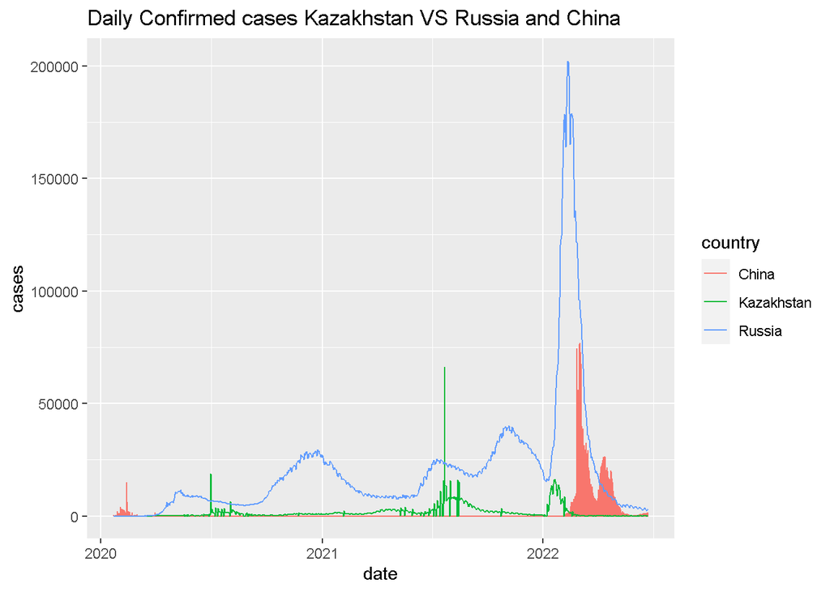

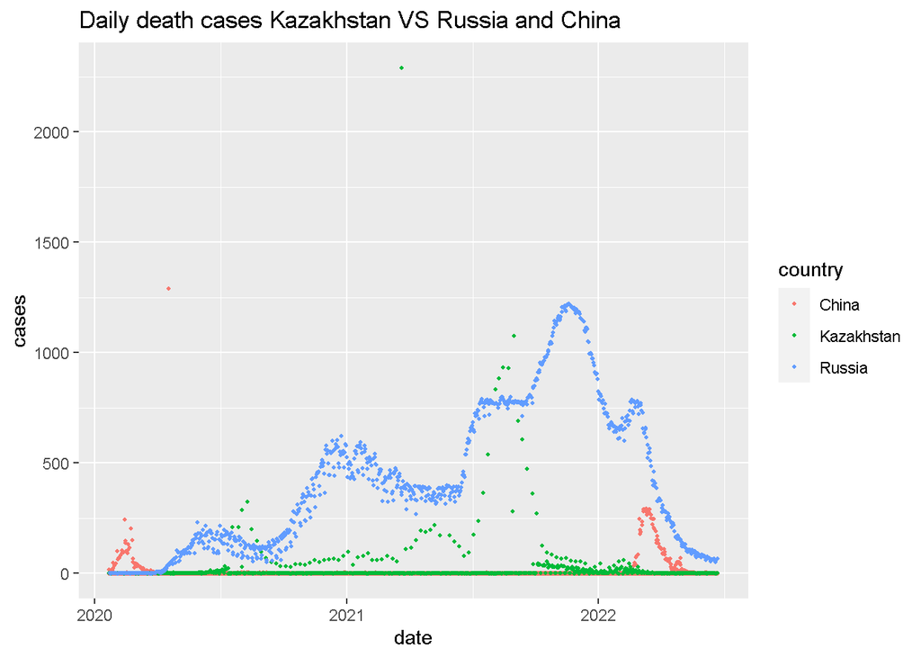

# 3.Discussion

The progress of COVID-19 of Kazakhstan cannot be clearly understood by solely analyzing Kazakhstan’s data, therefore a comparison of Kazakhstan with countries of significance during the COVID-19 pandemic has been carried out in order to reach the final conclusions.

Through the data analysis process it was recognized that there were negative values for confirmed cases of some countries, the main causes may be the fact that at preliminary stages of testing some patients may have been diagnosed as COVID-19 positive and later on diagnosed as negative. Therefore, the data was pre-processed before the actual analysis by coding the negative values as missing values. This is the reason as to why there are discontinuities in some line plots.

# 4.Conclusion

According to the graph of Daily covid 19 death, we can say that the death case rate is gradually increased after some day point of 2021.It was momentarily after some day point of 2021 year.Not only that according to the graph of Daily covid 19 recovered, there is no reported cases reported after some day point in 2021.

# 5.References

- Kazakhstan Introduction,viewed 1st October 2022 : [Kazakhstan Introduction](https://en.wikipedia.org/wiki/Kazakhstan)
- Population of Kazakhstan,viewed 1st october 2022 : [Population of the Republic of Kazakhstan](https://www.worldometers.info/world-population/kazakhstan-population/)
- Kazakhstan COVID 19 details,viewed 7th october 2022 : [Kazakhstan COVID 19 details](https://covid19.who.int/region/euro/country/kz)
- Demographic Of Kazakhstan,viewed on 7th October 2022 : [Demographic Of Kazakhstan](https://en.wikipedia.org/wiki/Demographics_of_Kazakhstan)